# Project: Gapminder World Dataset

- Introduction
- Data Wrangling
- Exploratory Data Analysis
- Conclusions

## Introduction

This report is an exploration of data on countries around the world. Gapminder World has collected a variety of data on how people live their lives across the globe. This report will try to identify trends in the following datasets for the United States:

- Life expectancy - The average number of years a newborn child would live if current mortality rates stayed the same
- Happiness score (WHR) - Measured using the Cantril life ladder which is explained below
- The income per person- GDP/capita with inflation adjusted to 2011 Purchasing Power Parity (PPP)
- The unemployment rate for individuals 15 years and over
- Working hours per week - Calucualted by the total amount of yearly working hours divided by 52 weeks

#### Cantril Life Ladder Method

It is the national average response to the question of life evaluations asking the following question: "Please imagine a ladder, with steps numbered from 0 at the bottom to 10 at the top. The top of the ladder represents the best possible life for you and the bottom of the ladder represents the worst life for you. On which stepof the ladder would you say you personally feel you stand at this time?" The dataset expresses the answers as a percentage

### The questions to explore are as follows:

1. Does a higher income lead to a higher life expectancy?
2. Does a higher unemployment rate lead to a lower life expectancy?
3. Does a higher hours worked per week lead to a higher life expectancy?
4. Does a higher hours worked per week lead to a happier nation?
5. Does a higher income mean a nation is more happy?
6. Does a higher unemployment rate mean a nation is less happy?

```python
import numpy as np
import pandas as pd
import matplotlib.pyplot as plt
from matplotlib.animation import FuncAnimation
import seaborn as sns
%matplotlib inline
```

## Data Wrangling

### General Properties

```python
df_life_exp = pd.read_csv('life_expectancy_years.csv')
df_happy = pd.read_csv('hapiscore_whr.csv')
df_income = pd.read_csv('income_per_person_gdppercapita_ppp_inflation_adjusted.csv')
df_unemp = pd.read_csv('aged_15plus_unemployment_rate_percent.csv')
df_work_hr = pd.read_csv('working_hours_per_week.csv')
```

### Data Cleaning for the _df_life*exp* dataframe

```python
df_life_exp.head()
```

|  | country | 1800 | 1801 | 1802 | 1803 | 1804 | 1805 | 1806 | 1807 | 1808 | ... | 2091 | 2092 | 2093 | 2094 | 2095 | 2096 | 2097 | 2098 | 2099 | 2100 |
| --- | --- | --- | --- | --- | --- | --- | --- | --- | --- | --- | --- | --- | --- | --- | --- | --- | --- | --- | --- | --- | --- |
| 0 | Afghanistan | 28.2 | 28.2 | 28.2 | 28.2 | 28.2 | 28.2 | 28.1 | 28.1 | 28.1 | ... | 76.5 | 76.6 | 76.7 | 76.9 | 77.0 | 77.1 | 77.3 | 77.4 | 77.5 | 77.7 |
| 1 | Albania | 35.4 | 35.4 | 35.4 | 35.4 | 35.4 | 35.4 | 35.4 | 35.4 | 35.4 | ... | 87.4 | 87.5 | 87.6 | 87.7 | 87.8 | 87.9 | 88.0 | 88.1 | 88.2 | 88.3 |
| 2 | Algeria | 28.8 | 28.8 | 28.8 | 28.8 | 28.8 | 28.8 | 28.8 | 28.8 | 28.8 | ... | 88.3 | 88.4 | 88.5 | 88.6 | 88.7 | 88.8 | 88.9 | 89.0 | 89.1 | 89.2 |
| 3 | Andorra | NaN | NaN | NaN | NaN | NaN | NaN | NaN | NaN | NaN | ... | NaN | NaN | NaN | NaN | NaN | NaN | NaN | NaN | NaN | NaN |
| 4 | Angola | 27.0 | 27.0 | 27.0 | 27.0 | 27.0 | 27.0 | 27.0 | 27.0 | 27.0 | ... | 78.7 | 78.9 | 79.0 | 79.1 | 79.3 | 79.4 | 79.5 | 79.7 | 79.8 | 79.9 |

5 rows × 302 columns

```python
df_life_exp.shape
```

```
(187, 302)
```

```python
df_life_exp.describe()
```

|  | 1800 | 1801 | 1802 | 1803 | 1804 | 1805 | 1806 | 1807 | 1808 | 1809 | ... | 2091 | 2092 | 2093 | 2094 | 2095 | 2096 | 2097 | 2098 | 2099 | 2100 |
| --- | --- | --- | --- | --- | --- | --- | --- | --- | --- | --- | --- | --- | --- | --- | --- | --- | --- | --- | --- | --- | --- |
| count | 184.000000 | 184.000000 | 184.000000 | 184.000000 | 184.000000 | 184.000000 | 184.000000 | 184.000000 | 184.000000 | 184.000000 | ... | 184.000000 | 184.00000 | 184.000000 | 184.000000 | 184.000000 | 184.000000 | 184.000000 | 184.000000 | 184.00000 | 184.000000 |
| mean | 31.502717 | 31.461957 | 31.478804 | 31.383152 | 31.459239 | 31.586413 | 31.644565 | 31.598370 | 31.383152 | 31.310326 | ... | 83.758152 | 83.87663 | 83.996196 | 84.119022 | 84.236957 | 84.358152 | 84.478804 | 84.593478 | 84.71087 | 84.829891 |
| std | 3.814689 | 3.806303 | 3.938674 | 3.962376 | 3.934674 | 4.010884 | 4.110598 | 3.981247 | 4.087872 | 4.040580 | ... | 5.600794 | 5.59444 | 5.589074 | 5.577601 | 5.570850 | 5.566060 | 5.556903 | 5.550234 | 5.54055 | 5.532609 |
| min | 23.400000 | 23.400000 | 23.400000 | 19.600000 | 23.400000 | 23.400000 | 23.400000 | 23.400000 | 12.500000 | 13.400000 | ... | 67.100000 | 67.30000 | 67.400000 | 67.500000 | 67.600000 | 67.700000 | 67.800000 | 67.900000 | 68.00000 | 68.100000 |
| 25% | 29.075000 | 28.975000 | 28.900000 | 28.900000 | 28.975000 | 29.075000 | 29.075000 | 29.075000 | 28.975000 | 28.875000 | ... | 79.500000 | 79.70000 | 79.800000 | 79.900000 | 80.075000 | 80.200000 | 80.375000 | 80.475000 | 80.57500 | 80.775000 |
| 50% | 31.750000 | 31.650000 | 31.550000 | 31.500000 | 31.550000 | 31.650000 | 31.750000 | 31.750000 | 31.550000 | 31.500000 | ... | 84.200000 | 84.35000 | 84.450000 | 84.550000 | 84.650000 | 84.750000 | 84.850000 | 85.000000 | 85.15000 | 85.250000 |
| 75% | 33.825000 | 33.900000 | 33.825000 | 33.625000 | 33.725000 | 33.825000 | 33.925000 | 33.925000 | 33.725000 | 33.625000 | ... | 88.125000 | 88.22500 | 88.325000 | 88.500000 | 88.600000 | 88.700000 | 88.800000 | 88.900000 | 89.00000 | 89.100000 |
| max | 42.900000 | 40.300000 | 44.400000 | 44.800000 | 42.800000 | 44.300000 | 45.800000 | 43.600000 | 43.500000 | 41.700000 | ... | 93.700000 | 93.90000 | 94.000000 | 94.100000 | 94.200000 | 94.300000 | 94.400000 | 94.500000 | 94.70000 | 94.800000 |

8 rows × 301 columns

We can see that this data has data that goes up to the year 2100. Since we are only interested in data up to the year 2019, the data for years beyond that will be trimmed off. From the df.shape we can see that we have 302 columns, and the last column is the year 2100, which is 81 years more than we need. So we will select the desired columns by doing 302-81 which equals 221. we will plug this into our .iloc function

```python
df_life_exp = df_life_exp.iloc[:, :221]
df_life_exp
```

|  | country | 1800 | 1801 | 1802 | 1803 | 1804 | 1805 | 1806 | 1807 | 1808 | ... | 2010 | 2011 | 2012 | 2013 | 2014 | 2015 | 2016 | 2017 | 2018 | 2019 |
| --- | --- | --- | --- | --- | --- | --- | --- | --- | --- | --- | --- | --- | --- | --- | --- | --- | --- | --- | --- | --- | --- |
| 0 | Afghanistan | 28.2 | 28.2 | 28.2 | 28.2 | 28.2 | 28.2 | 28.1 | 28.1 | 28.1 | ... | 59.9 | 60.4 | 60.8 | 61.3 | 61.2 | 61.2 | 61.2 | 63.4 | 63.7 | 64.1 |
| 1 | Albania | 35.4 | 35.4 | 35.4 | 35.4 | 35.4 | 35.4 | 35.4 | 35.4 | 35.4 | ... | 77.6 | 77.7 | 77.8 | 77.9 | 77.9 | 78.0 | 78.1 | 78.2 | 78.3 | 78.5 |
| 2 | Algeria | 28.8 | 28.8 | 28.8 | 28.8 | 28.8 | 28.8 | 28.8 | 28.8 | 28.8 | ... | 76.3 | 76.5 | 76.8 | 76.9 | 77.0 | 77.1 | 77.4 | 77.7 | 77.9 | 78.1 |
| 3 | Andorra | NaN | NaN | NaN | NaN | NaN | NaN | NaN | NaN | NaN | ... | 82.3 | 82.4 | 82.4 | 82.5 | 82.5 | 82.6 | 82.7 | 82.7 | NaN | NaN |
| 4 | Angola | 27.0 | 27.0 | 27.0 | 27.0 | 27.0 | 27.0 | 27.0 | 27.0 | 27.0 | ... | 59.9 | 60.6 | 61.3 | 61.9 | 62.8 | 63.3 | 63.8 | 64.2 | 64.6 | 65.0 |
| ... | ... | ... | ... | ... | ... | ... | ... | ... | ... | ... | ... | ... | ... | ... | ... | ... | ... | ... | ... | ... | ... |
| 182 | Venezuela | 32.2 | 32.2 | 32.2 | 32.2 | 32.2 | 32.2 | 32.2 | 32.2 | 32.2 | ... | 75.3 | 75.3 | 75.2 | 75.2 | 75.0 | 75.0 | 75.3 | 75.3 | 75.2 | 75.1 |
| 183 | Vietnam | 32.0 | 32.0 | 32.0 | 32.0 | 32.0 | 32.0 | 32.0 | 32.0 | 32.0 | ... | 73.5 | 73.6 | 73.8 | 74.0 | 74.1 | 74.3 | 74.4 | 74.5 | 74.6 | 74.7 |
| 184 | Yemen | 23.4 | 23.4 | 23.4 | 23.4 | 23.4 | 23.4 | 23.4 | 23.4 | 23.4 | ... | 68.0 | 68.1 | 68.3 | 68.9 | 69.0 | 68.6 | 68.1 | 68.1 | 68.1 | 68.1 |
| 185 | Zambia | 32.6 | 32.6 | 32.6 | 32.6 | 32.6 | 32.6 | 32.6 | 32.6 | 32.6 | ... | 56.0 | 57.5 | 58.8 | 60.0 | 61.1 | 62.0 | 62.8 | 63.2 | 63.7 | 64.0 |
| 186 | Zimbabwe | 33.7 | 33.7 | 33.7 | 33.7 | 33.7 | 33.7 | 33.7 | 33.7 | 33.7 | ... | 49.7 | 52.4 | 54.9 | 56.8 | 58.5 | 59.6 | 60.5 | 61.4 | 61.7 | 62.0 |

187 rows × 221 columns

```python
df_life_exp.info()
```

```
<class 'pandas.core.frame.DataFrame'>
RangeIndex: 187 entries, 0 to 186
Columns: 221 entries, country to 2019
dtypes: float64(220), object(1)
memory usage: 323.0+ KB
```

Next we will look at how many null values there are, and then drop the countries with null values

```python
df_life_exp.isnull().sum().sum()
```

```
516
```

```python
df_life_exp.dropna(inplace=True)
df_life_exp.isnull().sum().sum()
```

```
0
```

```python
df_life_exp.shape
```

```
(184, 221)
```

This changes the shape of the dataframe from (187, 302) to (184, 221)

```python
#create a list of the countires in df_life_exp
life_exp_countries = []
for i in df_life_exp['country']:
    if i not in life_exp_countries:
        life_exp_countries.append(i)
len(life_exp_countries)
```

```
184
```

```python
df_life_exp.dtypes
```

```
country     object
1800       float64
1801       float64
1802       float64
1803       float64
            ...
2015       float64
2016       float64
2017       float64
2018       float64
2019       float64
Length: 221, dtype: object
```

### Data Cleaning for the _df*happy* dataframe

```python
df_happy.head()
```

|  | country | 2005 | 2006 | 2007 | 2008 | 2009 | 2010 | 2011 | 2012 | 2013 | 2014 | 2015 | 2016 | 2017 | 2018 | 2019 |
| --- | --- | --- | --- | --- | --- | --- | --- | --- | --- | --- | --- | --- | --- | --- | --- | --- |
| 0 | Afghanistan | NaN | NaN | NaN | 0.372 | 0.440 | 0.476 | 0.383 | 0.378 | 0.357 | 0.313 | 0.398 | 0.422 | 0.266 | 0.269 | 0.257 |
| 1 | Albania | NaN | NaN | 0.463 | NaN | 0.549 | 0.527 | 0.587 | 0.551 | 0.455 | 0.481 | 0.461 | 0.451 | 0.464 | 0.500 | 0.488 |
| 2 | Algeria | NaN | NaN | NaN | NaN | NaN | 0.546 | 0.532 | 0.560 | NaN | 0.635 | NaN | 0.534 | 0.525 | 0.504 | 0.501 |
| 3 | Angola | NaN | NaN | NaN | NaN | NaN | NaN | 0.559 | 0.436 | 0.394 | 0.379 | NaN | NaN | NaN | NaN | NaN |
| 4 | Argentina | NaN | 0.631 | 0.607 | 0.596 | 0.642 | 0.644 | 0.678 | 0.647 | 0.658 | 0.667 | 0.670 | 0.643 | 0.604 | 0.579 | 0.597 |

```python
df_happy.info()
```

```
<class 'pandas.core.frame.DataFrame'>
RangeIndex: 161 entries, 0 to 160
Data columns (total 16 columns):
 #   Column   Non-Null Count  Dtype
---  ------   --------------  -----
 0   country  161 non-null    object
 1   2005     27 non-null     float64
 2   2006     87 non-null     float64
 3   2007     101 non-null    float64
 4   2008     107 non-null    float64
 5   2009     112 non-null    float64
 6   2010     121 non-null    float64
 7   2011     143 non-null    float64
 8   2012     138 non-null    float64
 9   2013     134 non-null    float64
 10  2014     141 non-null    float64
 11  2015     140 non-null    float64
 12  2016     138 non-null    float64
 13  2017     144 non-null    float64
 14  2018     133 non-null    float64
 15  2019     149 non-null    float64
dtypes: float64(15), object(1)
memory usage: 20.2+ KB
```

```python
df_happy.shape
```

```
(161, 16)
```

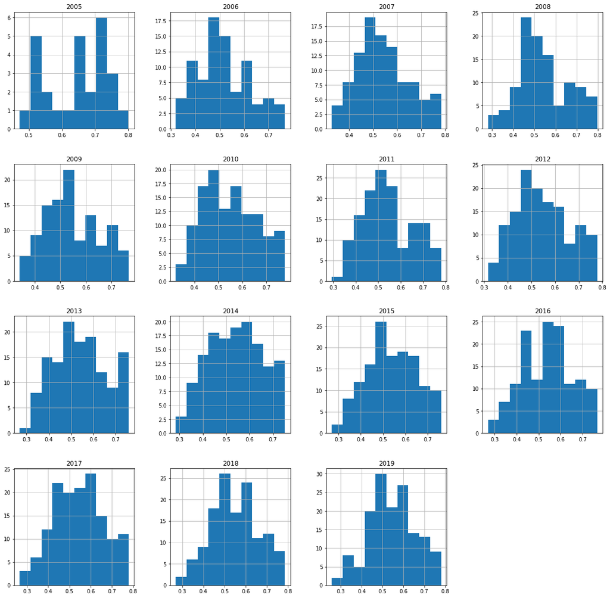

```python
df_happy.hist(figsize=(20,20));
```

```python
df_happy.describe()
```

|  | 2005 | 2006 | 2007 | 2008 | 2009 | 2010 | 2011 | 2012 | 2013 | 2014 | 2015 | 2016 | 2017 | 2018 | 2019 |
| --- | --- | --- | --- | --- | --- | --- | --- | --- | --- | --- | --- | --- | --- | --- | --- |
| count | 27.000000 | 87.000000 | 101.000000 | 107.000000 | 112.000000 | 121.000000 | 143.000000 | 138.000000 | 134.000000 | 141.00000 | 140.000000 | 138.000000 | 144.000000 | 133.000000 | 149.000000 |
| mean | 0.644593 | 0.518138 | 0.542119 | 0.541897 | 0.545438 | 0.549256 | 0.542189 | 0.543659 | 0.538104 | 0.53817 | 0.539543 | 0.538486 | 0.545007 | 0.548729 | 0.546013 |
| std | 0.091888 | 0.110137 | 0.105214 | 0.118547 | 0.103771 | 0.113714 | 0.109184 | 0.113156 | 0.118906 | 0.11683 | 0.112399 | 0.115215 | 0.114883 | 0.111007 | 0.112181 |
| min | 0.472000 | 0.320000 | 0.328000 | 0.281000 | 0.341000 | 0.323000 | 0.294000 | 0.316000 | 0.269000 | 0.28400 | 0.270000 | 0.269000 | 0.266000 | 0.269000 | 0.257000 |
| 25% | 0.554000 | 0.444000 | 0.467000 | 0.459000 | 0.465500 | 0.461000 | 0.469000 | 0.457750 | 0.450250 | 0.44800 | 0.461000 | 0.451250 | 0.461250 | 0.466000 | 0.468000 |
| 50% | 0.662000 | 0.508000 | 0.522000 | 0.517000 | 0.532500 | 0.546000 | 0.522000 | 0.521500 | 0.524000 | 0.53100 | 0.533000 | 0.537000 | 0.551500 | 0.543000 | 0.550000 |
| 75% | 0.716000 | 0.592500 | 0.614000 | 0.633500 | 0.627250 | 0.635000 | 0.635500 | 0.625750 | 0.630500 | 0.62800 | 0.626000 | 0.613500 | 0.624000 | 0.628000 | 0.623000 |
| max | 0.802000 | 0.767000 | 0.783000 | 0.797000 | 0.768000 | 0.777000 | 0.779000 | 0.778000 | 0.759000 | 0.75100 | 0.760000 | 0.766000 | 0.779000 | 0.786000 | 0.781000 |

```python
df_happy.shape
```

```
(161, 16)
```

```python
df_happy.duplicated().sum()
```

```
0
```

```python
country_happy_avg = df_happy.mean(axis=1)
country_happy_avg
```

```
0      0.360917
1      0.498083
2      0.542125
3      0.442000
4      0.633071
         ...
156    0.612214
157    0.529714
158    0.385750
159    0.456385
160    0.397857
Length: 161, dtype: float64
```

```python
df_happy = df_happy.T.fillna(df_happy.mean(axis=1)).T
```

```python
df_happy
```

|  | country | 2005 | 2006 | 2007 | 2008 | 2009 | 2010 | 2011 | 2012 | 2013 | 2014 | 2015 | 2016 | 2017 | 2018 | 2019 |
| --- | --- | --- | --- | --- | --- | --- | --- | --- | --- | --- | --- | --- | --- | --- | --- | --- |
| 0 | Afghanistan | 0.360917 | 0.360917 | 0.360917 | 0.372 | 0.44 | 0.476 | 0.383 | 0.378 | 0.357 | 0.313 | 0.398 | 0.422 | 0.266 | 0.269 | 0.257 |
| 1 | Albania | 0.498083 | 0.498083 | 0.463 | 0.498083 | 0.549 | 0.527 | 0.587 | 0.551 | 0.455 | 0.481 | 0.461 | 0.451 | 0.464 | 0.5 | 0.488 |
| 2 | Algeria | 0.542125 | 0.542125 | 0.542125 | 0.542125 | 0.542125 | 0.546 | 0.532 | 0.56 | 0.542125 | 0.635 | 0.542125 | 0.534 | 0.525 | 0.504 | 0.501 |
| 3 | Angola | 0.442 | 0.442 | 0.442 | 0.442 | 0.442 | 0.442 | 0.559 | 0.436 | 0.394 | 0.379 | 0.442 | 0.442 | 0.442 | 0.442 | 0.442 |
| 4 | Argentina | 0.633071 | 0.631 | 0.607 | 0.596 | 0.642 | 0.644 | 0.678 | 0.647 | 0.658 | 0.667 | 0.67 | 0.643 | 0.604 | 0.579 | 0.597 |
| ... | ... | ... | ... | ... | ... | ... | ... | ... | ... | ... | ... | ... | ... | ... | ... | ... |
| 156 | Venezuela | 0.717 | 0.653 | 0.612214 | 0.626 | 0.719 | 0.748 | 0.658 | 0.707 | 0.655 | 0.614 | 0.557 | 0.404 | 0.507 | 0.501 | 0.505 |
| 157 | Vietnam | 0.529714 | 0.529 | 0.542 | 0.548 | 0.53 | 0.53 | 0.577 | 0.553 | 0.502 | 0.508 | 0.508 | 0.506 | 0.518 | 0.53 | 0.535 |
| 158 | Yemen | 0.38575 | 0.38575 | 0.448 | 0.38575 | 0.481 | 0.435 | 0.375 | 0.406 | 0.422 | 0.397 | 0.298 | 0.383 | 0.325 | 0.306 | 0.353 |
| 159 | Zambia | 0.456385 | 0.482 | 0.4 | 0.473 | 0.526 | 0.456385 | 0.5 | 0.501 | 0.524 | 0.435 | 0.484 | 0.435 | 0.393 | 0.404 | 0.376 |
| 160 | Zimbabwe | 0.397857 | 0.383 | 0.328 | 0.317 | 0.406 | 0.468 | 0.485 | 0.496 | 0.469 | 0.418 | 0.37 | 0.374 | 0.364 | 0.362 | 0.33 |

161 rows × 16 columns

```python
df_happy.duplicated().sum()
```

```
0
```

```python
df_happy.isnull().sum().sum()
```

```
0
```

```python
df_happy.dtypes
```

```
country    object
2005       object
2006       object
2007       object
2008       object
2009       object
2010       object
2011       object
2012       object
2013       object
2014       object
2015       object
2016       object
2017       object
2018       object
2019       object
dtype: object
```

Notice that after applying the mean to fiil the NaN values the datatype was changed to object, so we need to change it back to a float

```python
df_h = df_happy.iloc[:, 1:].astype(float)
```

```python
df_h.dtypes
```

```
2005    float64
2006    float64
2007    float64
2008    float64
2009    float64
2010    float64
2011    float64
2012    float64
2013    float64
2014    float64
2015    float64
2016    float64
2017    float64
2018    float64
2019    float64
dtype: object
```

```python
df_h_c = df_happy['country']
df_h_c.to_frame()
```

|  | country |
| --- | --- |
| 0 | Afghanistan |
| 1 | Albania |
| 2 | Algeria |
| 3 | Angola |
| 4 | Argentina |
| ... | ... |
| 156 | Venezuela |
| 157 | Vietnam |
| 158 | Yemen |
| 159 | Zambia |
| 160 | Zimbabwe |

161 rows × 1 columns

```python
df_happy_float = df_h_c.to_frame().join(df_h)
df_happy_float
```

|  | country | 2005 | 2006 | 2007 | 2008 | 2009 | 2010 | 2011 | 2012 | 2013 | 2014 | 2015 | 2016 | 2017 | 2018 | 2019 |
| --- | --- | --- | --- | --- | --- | --- | --- | --- | --- | --- | --- | --- | --- | --- | --- | --- |
| 0 | Afghanistan | 0.360917 | 0.360917 | 0.360917 | 0.372000 | 0.440000 | 0.476000 | 0.383 | 0.378 | 0.357000 | 0.313 | 0.398000 | 0.422 | 0.266 | 0.269 | 0.257 |
| 1 | Albania | 0.498083 | 0.498083 | 0.463000 | 0.498083 | 0.549000 | 0.527000 | 0.587 | 0.551 | 0.455000 | 0.481 | 0.461000 | 0.451 | 0.464 | 0.500 | 0.488 |
| 2 | Algeria | 0.542125 | 0.542125 | 0.542125 | 0.542125 | 0.542125 | 0.546000 | 0.532 | 0.560 | 0.542125 | 0.635 | 0.542125 | 0.534 | 0.525 | 0.504 | 0.501 |
| 3 | Angola | 0.442000 | 0.442000 | 0.442000 | 0.442000 | 0.442000 | 0.442000 | 0.559 | 0.436 | 0.394000 | 0.379 | 0.442000 | 0.442 | 0.442 | 0.442 | 0.442 |
| 4 | Argentina | 0.633071 | 0.631000 | 0.607000 | 0.596000 | 0.642000 | 0.644000 | 0.678 | 0.647 | 0.658000 | 0.667 | 0.670000 | 0.643 | 0.604 | 0.579 | 0.597 |
| ... | ... | ... | ... | ... | ... | ... | ... | ... | ... | ... | ... | ... | ... | ... | ... | ... |
| 156 | Venezuela | 0.717000 | 0.653000 | 0.612214 | 0.626000 | 0.719000 | 0.748000 | 0.658 | 0.707 | 0.655000 | 0.614 | 0.557000 | 0.404 | 0.507 | 0.501 | 0.505 |
| 157 | Vietnam | 0.529714 | 0.529000 | 0.542000 | 0.548000 | 0.530000 | 0.530000 | 0.577 | 0.553 | 0.502000 | 0.508 | 0.508000 | 0.506 | 0.518 | 0.530 | 0.535 |
| 158 | Yemen | 0.385750 | 0.385750 | 0.448000 | 0.385750 | 0.481000 | 0.435000 | 0.375 | 0.406 | 0.422000 | 0.397 | 0.298000 | 0.383 | 0.325 | 0.306 | 0.353 |
| 159 | Zambia | 0.456385 | 0.482000 | 0.400000 | 0.473000 | 0.526000 | 0.456385 | 0.500 | 0.501 | 0.524000 | 0.435 | 0.484000 | 0.435 | 0.393 | 0.404 | 0.376 |
| 160 | Zimbabwe | 0.397857 | 0.383000 | 0.328000 | 0.317000 | 0.406000 | 0.468000 | 0.485 | 0.496 | 0.469000 | 0.418 | 0.370000 | 0.374 | 0.364 | 0.362 | 0.330 |

161 rows × 16 columns

```python
df_happy_float.dtypes
```

```
country     object
2005       float64
2006       float64
2007       float64
2008       float64
2009       float64
2010       float64
2011       float64
2012       float64
2013       float64
2014       float64
2015       float64
2016       float64
2017       float64
2018       float64
2019       float64
dtype: object
```

we can see now that the countries column has been added back and that the happiness scores are back to floats

```python
#create a list of countries in df_happy
happy_countries = []
for i in df_happy['country']:
    if i not in happy_countries:
        happy_countries.append(i)
len(happy_countries)
```

```
161
```

### Data Cleaning for the _df*income* dataframe

```python
df_income
```

|  | country | 1800 | 1801 | 1802 | 1803 | 1804 | 1805 | 1806 | 1807 | 1808 | ... | 2031 | 2032 | 2033 | 2034 | 2035 | 2036 | 2037 | 2038 | 2039 | 2040 |
| --- | --- | --- | --- | --- | --- | --- | --- | --- | --- | --- | --- | --- | --- | --- | --- | --- | --- | --- | --- | --- | --- |
| 0 | Afghanistan | 603 | 603 | 603 | 603 | 603 | 603 | 603 | 603 | 603 | ... | 2550 | 2600 | 2660 | 2710 | 2770 | 2820 | 2880 | 2940 | 3000 | 3060 |
| 1 | Albania | 667 | 667 | 667 | 667 | 667 | 668 | 668 | 668 | 668 | ... | 19400 | 19800 | 20200 | 20600 | 21000 | 21500 | 21900 | 22300 | 22800 | 23300 |
| 2 | Algeria | 715 | 716 | 717 | 718 | 719 | 720 | 721 | 722 | 723 | ... | 14300 | 14600 | 14900 | 15200 | 15500 | 15800 | 16100 | 16500 | 16800 | 17100 |
| 3 | Andorra | 1200 | 1200 | 1200 | 1200 | 1210 | 1210 | 1210 | 1210 | 1220 | ... | 73600 | 75100 | 76700 | 78300 | 79900 | 81500 | 83100 | 84800 | 86500 | 88300 |
| 4 | Angola | 618 | 620 | 623 | 626 | 628 | 631 | 634 | 637 | 640 | ... | 6110 | 6230 | 6350 | 6480 | 6610 | 6750 | 6880 | 7020 | 7170 | 7310 |
| ... | ... | ... | ... | ... | ... | ... | ... | ... | ... | ... | ... | ... | ... | ... | ... | ... | ... | ... | ... | ... | ... |
| 188 | Venezuela | 1210 | 1200 | 1200 | 1190 | 1190 | 1180 | 1170 | 1170 | 1160 | ... | 8270 | 8420 | 8580 | 8760 | 8930 | 9110 | 9300 | 9490 | 9680 | 9880 |
| 189 | Vietnam | 778 | 778 | 778 | 778 | 778 | 778 | 778 | 778 | 778 | ... | 11900 | 12200 | 12500 | 12700 | 13000 | 13300 | 13500 | 13800 | 14100 | 14400 |
| 190 | Yemen | 877 | 879 | 882 | 884 | 887 | 889 | 892 | 894 | 897 | ... | 3230 | 3290 | 3360 | 3430 | 3500 | 3570 | 3640 | 3720 | 3790 | 3870 |
| 191 | Zambia | 663 | 665 | 667 | 668 | 670 | 671 | 673 | 675 | 676 | ... | 3500 | 3560 | 3630 | 3700 | 3780 | 3860 | 3930 | 4010 | 4100 | 4180 |
| 192 | Zimbabwe | 869 | 870 | 871 | 872 | 873 | 874 | 875 | 876 | 877 | ... | 2630 | 2680 | 2730 | 2780 | 2840 | 2900 | 2960 | 3020 | 3080 | 3140 |

193 rows × 242 columns

```python
df_income.shape
```

```
(193, 242)
```

```python
df_income.duplicated().sum()
```

```
0
```

```python
df_income.info()
```

```
<class 'pandas.core.frame.DataFrame'>
RangeIndex: 193 entries, 0 to 192
Columns: 242 entries, country to 2040
dtypes: int64(241), object(1)
memory usage: 365.0+ KB
```

```python
df_income.describe()
```

|  | 1800 | 1801 | 1802 | 1803 | 1804 | 1805 | 1806 | 1807 | 1808 | 1809 | ... | 2031 | 2032 | 2033 | 2034 | 2035 | 2036 | 2037 | 2038 | 2039 | 2040 |
| --- | --- | --- | --- | --- | --- | --- | --- | --- | --- | --- | --- | --- | --- | --- | --- | --- | --- | --- | --- | --- | --- |
| count | 193.000000 | 193.000000 | 193.000000 | 193.000000 | 193.000000 | 193.000000 | 193.000000 | 193.000000 | 193.000000 | 193.000000 | ... | 193.000000 | 193.000000 | 193.000000 | 193.000000 | 193.000000 | 193.000000 | 193.000000 | 193.000000 | 193.000000 | 193.000000 |
| mean | 978.523316 | 978.948187 | 980.725389 | 980.922280 | 981.911917 | 982.502591 | 982.829016 | 985.419689 | 980.937824 | 982.393782 | ... | 23142.378238 | 23613.119171 | 24083.461140 | 24577.430052 | 25077.678756 | 25576.476684 | 26107.564767 | 26635.953368 | 27180.512953 | 27730.725389 |
| std | 579.633227 | 579.915248 | 582.565512 | 582.032626 | 583.963199 | 584.043985 | 584.097850 | 590.514505 | 578.200194 | 581.878397 | ... | 23670.673835 | 24162.379036 | 24635.072766 | 25136.440969 | 25646.475260 | 26138.360102 | 26707.571366 | 27233.418469 | 27813.430077 | 28356.570830 |
| min | 250.000000 | 250.000000 | 249.000000 | 249.000000 | 249.000000 | 249.000000 | 248.000000 | 248.000000 | 248.000000 | 248.000000 | ... | 557.000000 | 566.000000 | 577.000000 | 588.000000 | 600.000000 | 612.000000 | 625.000000 | 637.000000 | 650.000000 | 664.000000 |
| 25% | 592.000000 | 592.000000 | 592.000000 | 592.000000 | 592.000000 | 593.000000 | 593.000000 | 593.000000 | 593.000000 | 593.000000 | ... | 5180.000000 | 5280.000000 | 5380.000000 | 5490.000000 | 5600.000000 | 5710.000000 | 5830.000000 | 5950.000000 | 6070.000000 | 6190.000000 |
| 50% | 817.000000 | 822.000000 | 826.000000 | 831.000000 | 836.000000 | 836.000000 | 836.000000 | 836.000000 | 836.000000 | 836.000000 | ... | 15400.000000 | 15700.000000 | 16000.000000 | 16400.000000 | 16700.000000 | 17000.000000 | 17400.000000 | 17700.000000 | 18100.000000 | 18500.000000 |
| 75% | 1160.000000 | 1170.000000 | 1170.000000 | 1170.000000 | 1170.000000 | 1170.000000 | 1170.000000 | 1170.000000 | 1160.000000 | 1170.000000 | ... | 34200.000000 | 34800.000000 | 35500.000000 | 36200.000000 | 37000.000000 | 37700.000000 | 38500.000000 | 39300.000000 | 40100.000000 | 40900.000000 |
| max | 3840.000000 | 3840.000000 | 3840.000000 | 3840.000000 | 3840.000000 | 3840.000000 | 3840.000000 | 3840.000000 | 3840.000000 | 3840.000000 | ... | 149000.000000 | 153000.000000 | 156000.000000 | 159000.000000 | 162000.000000 | 165000.000000 | 169000.000000 | 172000.000000 | 176000.000000 | 179000.000000 |

8 rows × 241 columns

```python
df_income.dtypes
```

```
country    object
1800        int64
1801        int64
1802        int64
1803        int64
            ...
2036        int64
2037        int64
2038        int64
2039        int64
2040        int64
Length: 242, dtype: object
```

```python
#trim the data set to only have values up to the year 2019
df_income_2019 = df_income.iloc[:,:-21]
df_income_2019
```

|  | country | 1800 | 1801 | 1802 | 1803 | 1804 | 1805 | 1806 | 1807 | 1808 | ... | 2010 | 2011 | 2012 | 2013 | 2014 | 2015 | 2016 | 2017 | 2018 | 2019 |
| --- | --- | --- | --- | --- | --- | --- | --- | --- | --- | --- | --- | --- | --- | --- | --- | --- | --- | --- | --- | --- | --- |
| 0 | Afghanistan | 603 | 603 | 603 | 603 | 603 | 603 | 603 | 603 | 603 | ... | 1670 | 1630 | 1770 | 1810 | 1800 | 1770 | 1760 | 1760 | 1740 | 1760 |
| 1 | Albania | 667 | 667 | 667 | 667 | 667 | 668 | 668 | 668 | 668 | ... | 9930 | 10200 | 10400 | 10500 | 10700 | 11000 | 11400 | 11800 | 12300 | 12700 |
| 2 | Algeria | 715 | 716 | 717 | 718 | 719 | 720 | 721 | 722 | 723 | ... | 12900 | 13000 | 13200 | 13300 | 13500 | 13800 | 13900 | 13900 | 13900 | 14000 |
| 3 | Andorra | 1200 | 1200 | 1200 | 1200 | 1210 | 1210 | 1210 | 1210 | 1220 | ... | 39000 | 42000 | 41900 | 43700 | 44900 | 46600 | 48200 | 49800 | 51500 | 53200 |
| 4 | Angola | 618 | 620 | 623 | 626 | 628 | 631 | 634 | 637 | 640 | ... | 6360 | 6350 | 6650 | 6730 | 6810 | 6650 | 6260 | 6050 | 5730 | 5540 |
| ... | ... | ... | ... | ... | ... | ... | ... | ... | ... | ... | ... | ... | ... | ... | ... | ... | ... | ... | ... | ... | ... |
| 188 | Venezuela | 1210 | 1200 | 1200 | 1190 | 1190 | 1180 | 1170 | 1170 | 1160 | ... | 16900 | 17300 | 18000 | 18000 | 17100 | 15600 | 15200 | 14500 | 12500 | 9720 |
| 189 | Vietnam | 778 | 778 | 778 | 778 | 778 | 778 | 778 | 778 | 778 | ... | 4430 | 4660 | 4860 | 5070 | 5310 | 5610 | 5900 | 6230 | 6610 | 6970 |
| 190 | Yemen | 877 | 879 | 882 | 884 | 887 | 889 | 892 | 894 | 897 | ... | 4570 | 3880 | 3860 | 3940 | 3830 | 3110 | 2620 | 2400 | 2360 | 2340 |
| 191 | Zambia | 663 | 665 | 667 | 668 | 670 | 671 | 673 | 675 | 676 | ... | 3340 | 3420 | 3570 | 3630 | 3690 | 3680 | 3700 | 3720 | 3740 | 3700 |
| 192 | Zimbabwe | 869 | 870 | 871 | 872 | 873 | 874 | 875 | 876 | 877 | ... | 1930 | 2170 | 2490 | 2490 | 2510 | 2510 | 2490 | 2570 | 2620 | 2390 |

193 rows × 221 columns

```python
df_income_2019.isnull().sum().sum()
```

```
0
```

### Data Cleaning for the _df*unemp* dataframe

```python
df_unemp
```

|  | country | 1947 | 1948 | 1949 | 1950 | 1951 | 1952 | 1953 | 1954 | 1955 | ... | 2008 | 2009 | 2010 | 2011 | 2012 | 2013 | 2014 | 2015 | 2016 | 2017 |
| --- | --- | --- | --- | --- | --- | --- | --- | --- | --- | --- | --- | --- | --- | --- | --- | --- | --- | --- | --- | --- | --- |
| 0 | Afghanistan | NaN | NaN | NaN | NaN | NaN | NaN | NaN | NaN | NaN | ... | 0.0249 | NaN | NaN | NaN | 0.0169 | NaN | NaN | NaN | NaN | NaN |
| 1 | Albania | NaN | NaN | NaN | NaN | NaN | NaN | NaN | NaN | NaN | ... | 0.1310 | 0.1370 | 0.1410 | 0.13500 | 0.1340 | 0.1590 | 0.1750 | 0.1710 | 0.1520 | 0.1380 |
| 2 | Algeria | NaN | NaN | NaN | NaN | NaN | NaN | NaN | NaN | NaN | ... | 0.1130 | 0.1020 | 0.0996 | 0.09960 | 0.1100 | 0.0982 | 0.1020 | 0.1120 | 0.1020 | 0.1360 |
| 3 | Angola | NaN | NaN | NaN | NaN | NaN | NaN | NaN | NaN | NaN | ... | NaN | NaN | 0.0943 | 0.16800 | NaN | NaN | NaN | NaN | NaN | NaN |
| 4 | Antigua and Barbuda | NaN | NaN | NaN | NaN | NaN | NaN | NaN | NaN | NaN | ... | NaN | NaN | NaN | NaN | NaN | NaN | NaN | NaN | NaN | NaN |
| ... | ... | ... | ... | ... | ... | ... | ... | ... | ... | ... | ... | ... | ... | ... | ... | ... | ... | ... | ... | ... | ... |
| 181 | Venezuela | NaN | NaN | NaN | NaN | NaN | NaN | NaN | NaN | NaN | ... | 0.0625 | 0.0610 | 0.0711 | 0.06900 | 0.0660 | NaN | NaN | NaN | NaN | NaN |
| 182 | Vietnam | NaN | NaN | NaN | NaN | NaN | NaN | NaN | NaN | NaN | ... | 0.0238 | 0.0174 | 0.0111 | 0.00999 | 0.0103 | 0.0125 | 0.0126 | 0.0186 | 0.0185 | 0.0189 |
| 183 | Yemen | NaN | NaN | NaN | NaN | NaN | NaN | NaN | NaN | NaN | ... | NaN | NaN | NaN | NaN | NaN | NaN | 0.1350 | NaN | NaN | NaN |
| 184 | Zambia | NaN | NaN | NaN | NaN | NaN | NaN | NaN | NaN | NaN | ... | 0.0793 | NaN | NaN | NaN | 0.0785 | NaN | NaN | NaN | NaN | NaN |
| 185 | Zimbabwe | NaN | NaN | NaN | NaN | NaN | NaN | NaN | NaN | NaN | ... | NaN | NaN | NaN | 0.05370 | NaN | NaN | 0.1130 | NaN | NaN | NaN |

186 rows × 72 columns

```python
df_unemp.isnull().sum().sum()
```

```
10178
```

```python
df_unemp.describe()
```

|  | 1947 | 1948 | 1949 | 1950 | 1951 | 1952 | 1953 | 1954 | 1955 | 1956 | ... | 2008 | 2009 | 2010 | 2011 | 2012 | 2013 | 2014 | 2015 | 2016 | 2017 |
| --- | --- | --- | --- | --- | --- | --- | --- | --- | --- | --- | --- | --- | --- | --- | --- | --- | --- | --- | --- | --- | --- |
| count | 1.000 | 1.000 | 1.000 | 1.000 | 1.000 | 1.00 | 2.000000 | 2.000000 | 2.000000 | 2.000000 | ... | 98.000000 | 103.000000 | 107.000000 | 101.000000 | 109.000000 | 104.000000 | 109.000000 | 105.000000 | 105.000000 | 92.000000 |
| mean | 0.039 | 0.038 | 0.059 | 0.053 | 0.033 | 0.03 | 0.024000 | 0.039000 | 0.034500 | 0.032000 | ... | 0.075865 | 0.085512 | 0.085181 | 0.087914 | 0.089051 | 0.092544 | 0.086416 | 0.087794 | 0.084108 | 0.080075 |
| std | NaN | NaN | NaN | NaN | NaN | NaN | 0.007071 | 0.022627 | 0.013435 | 0.012728 | ... | 0.058822 | 0.052846 | 0.061635 | 0.061161 | 0.062024 | 0.066562 | 0.062003 | 0.066966 | 0.059509 | 0.054533 |
| min | 0.039 | 0.038 | 0.059 | 0.053 | 0.033 | 0.03 | 0.019000 | 0.023000 | 0.025000 | 0.023000 | ... | 0.003100 | 0.003100 | 0.006220 | 0.005600 | 0.004800 | 0.002700 | 0.001900 | 0.001600 | 0.001400 | 0.001400 |
| 25% | 0.039 | 0.038 | 0.059 | 0.053 | 0.033 | 0.03 | 0.021500 | 0.031000 | 0.029750 | 0.027500 | ... | 0.041475 | 0.053600 | 0.042400 | 0.045600 | 0.048700 | 0.046725 | 0.048000 | 0.045600 | 0.046000 | 0.042025 |
| 50% | 0.039 | 0.038 | 0.059 | 0.053 | 0.033 | 0.03 | 0.024000 | 0.039000 | 0.034500 | 0.032000 | ... | 0.062400 | 0.077400 | 0.073700 | 0.071800 | 0.074700 | 0.070850 | 0.066600 | 0.068100 | 0.064500 | 0.062500 |
| 75% | 0.039 | 0.038 | 0.059 | 0.053 | 0.033 | 0.03 | 0.026500 | 0.047000 | 0.039250 | 0.036500 | ... | 0.084450 | 0.101000 | 0.101300 | 0.113000 | 0.116000 | 0.118250 | 0.108000 | 0.104000 | 0.101000 | 0.098325 |
| max | 0.039 | 0.038 | 0.059 | 0.053 | 0.033 | 0.03 | 0.029000 | 0.055000 | 0.044000 | 0.041000 | ... | 0.355000 | 0.322000 | 0.320000 | 0.314000 | 0.310000 | 0.290000 | 0.280000 | 0.365000 | 0.269000 | 0.274000 |

8 rows × 71 columns

```python
country_unemp_avg = df_unemp.mean(axis=1)
country_unemp_avg
```

```
0      0.020900
1      0.148455
2      0.178850
3      0.131150
4      0.060000
         ...
181    0.088543
182    0.019175
183    0.125000
184    0.111700
185    0.065900
Length: 186, dtype: float64
```

```python
df_unemp = df_unemp.T.fillna(df_unemp.mean(axis=1)).T
```

```python
df_unemp
```

|  | country | 1947 | 1948 | 1949 | 1950 | 1951 | 1952 | 1953 | 1954 | 1955 | ... | 2008 | 2009 | 2010 | 2011 | 2012 | 2013 | 2014 | 2015 | 2016 | 2017 |
| --- | --- | --- | --- | --- | --- | --- | --- | --- | --- | --- | --- | --- | --- | --- | --- | --- | --- | --- | --- | --- | --- |
| 0 | Afghanistan | 0.0209 | 0.0209 | 0.0209 | 0.0209 | 0.0209 | 0.0209 | 0.0209 | 0.0209 | 0.0209 | ... | 0.0249 | 0.0209 | 0.0209 | 0.0209 | 0.0169 | 0.0209 | 0.0209 | 0.0209 | 0.0209 | 0.0209 |
| 1 | Albania | 0.148455 | 0.148455 | 0.148455 | 0.148455 | 0.148455 | 0.148455 | 0.148455 | 0.148455 | 0.148455 | ... | 0.131 | 0.137 | 0.141 | 0.135 | 0.134 | 0.159 | 0.175 | 0.171 | 0.152 | 0.138 |
| 2 | Algeria | 0.17885 | 0.17885 | 0.17885 | 0.17885 | 0.17885 | 0.17885 | 0.17885 | 0.17885 | 0.17885 | ... | 0.113 | 0.102 | 0.0996 | 0.0996 | 0.11 | 0.0982 | 0.102 | 0.112 | 0.102 | 0.136 |
| 3 | Angola | 0.13115 | 0.13115 | 0.13115 | 0.13115 | 0.13115 | 0.13115 | 0.13115 | 0.13115 | 0.13115 | ... | 0.13115 | 0.13115 | 0.0943 | 0.168 | 0.13115 | 0.13115 | 0.13115 | 0.13115 | 0.13115 | 0.13115 |
| 4 | Antigua and Barbuda | 0.06 | 0.06 | 0.06 | 0.06 | 0.06 | 0.06 | 0.06 | 0.06 | 0.06 | ... | 0.06 | 0.06 | 0.06 | 0.06 | 0.06 | 0.06 | 0.06 | 0.06 | 0.06 | 0.06 |
| ... | ... | ... | ... | ... | ... | ... | ... | ... | ... | ... | ... | ... | ... | ... | ... | ... | ... | ... | ... | ... | ... |
| 181 | Venezuela | 0.0885429 | 0.0885429 | 0.0885429 | 0.0885429 | 0.0885429 | 0.0885429 | 0.0885429 | 0.0885429 | 0.0885429 | ... | 0.0625 | 0.061 | 0.0711 | 0.069 | 0.066 | 0.0885429 | 0.0885429 | 0.0885429 | 0.0885429 | 0.0885429 |
| 182 | Vietnam | 0.0191745 | 0.0191745 | 0.0191745 | 0.0191745 | 0.0191745 | 0.0191745 | 0.0191745 | 0.0191745 | 0.0191745 | ... | 0.0238 | 0.0174 | 0.0111 | 0.00999 | 0.0103 | 0.0125 | 0.0126 | 0.0186 | 0.0185 | 0.0189 |
| 183 | Yemen | 0.125 | 0.125 | 0.125 | 0.125 | 0.125 | 0.125 | 0.125 | 0.125 | 0.125 | ... | 0.125 | 0.125 | 0.125 | 0.125 | 0.125 | 0.125 | 0.135 | 0.125 | 0.125 | 0.125 |
| 184 | Zambia | 0.1117 | 0.1117 | 0.1117 | 0.1117 | 0.1117 | 0.1117 | 0.1117 | 0.1117 | 0.1117 | ... | 0.0793 | 0.1117 | 0.1117 | 0.1117 | 0.0785 | 0.1117 | 0.1117 | 0.1117 | 0.1117 | 0.1117 |
| 185 | Zimbabwe | 0.0659 | 0.0659 | 0.0659 | 0.0659 | 0.0659 | 0.0659 | 0.0659 | 0.0659 | 0.0659 | ... | 0.0659 | 0.0659 | 0.0659 | 0.0537 | 0.0659 | 0.0659 | 0.113 | 0.0659 | 0.0659 | 0.0659 |

186 rows × 72 columns

```python
df_unemp.isnull().sum().sum()
```

```
0
```

```python
df_unemp.describe()
```

|  | country | 1947 | 1948 | 1949 | 1950 | 1951 | 1952 | 1953 | 1954 | 1955 | ... | 2008 | 2009 | 2010 | 2011 | 2012 | 2013 | 2014 | 2015 | 2016 | 2017 |
| --- | --- | --- | --- | --- | --- | --- | --- | --- | --- | --- | --- | --- | --- | --- | --- | --- | --- | --- | --- | --- | --- |
| count | 186 | 186.0000 | 186.0000 | 186.0000 | 186.0000 | 186.0000 | 186.0000 | 186.0000 | 186.0000 | 186.0000 | ... | 186.000 | 186.0 | 186.00 | 186.0000 | 186.000 | 186.000 | 186.000 | 186.0000 | 186.0000 | 186.000 |
| unique | 186 | 186.0000 | 186.0000 | 186.0000 | 186.0000 | 186.0000 | 186.0000 | 186.0000 | 186.0000 | 186.0000 | ... | 180.000 | 172.0 | 178.00 | 175.0000 | 171.000 | 175.000 | 175.000 | 176.0000 | 178.0000 | 178.000 |
| top | South Africa | 0.0271 | 0.0271 | 0.0271 | 0.0271 | 0.0271 | 0.0271 | 0.0271 | 0.0271 | 0.0271 | ... | 0.113 | 0.1 | 0.13 | 0.0411 | 0.168 | 0.159 | 0.036 | 0.0681 | 0.0681 | 0.112 |
| freq | 1 | 1.0000 | 1.0000 | 1.0000 | 1.0000 | 1.0000 | 1.0000 | 1.0000 | 1.0000 | 1.0000 | ... | 3.000 | 3.0 | 2.00 | 3.0000 | 2.000 | 3.000 | 3.000 | 3.0000 | 2.0000 | 2.000 |

4 rows × 72 columns

```python
df_unemp.duplicated().sum()
```

```
0
```

### Data Cleaning for the _df_work*hr* dataframe

```python
df_work_hr
```

|  | country | 1970 | 1971 | 1972 | 1973 | 1974 | 1975 | 1976 | 1977 | 1978 | ... | 2008 | 2009 | 2010 | 2011 | 2012 | 2013 | 2014 | 2015 | 2016 | 2017 |
| --- | --- | --- | --- | --- | --- | --- | --- | --- | --- | --- | --- | --- | --- | --- | --- | --- | --- | --- | --- | --- | --- |
| 0 | Albania | NaN | NaN | NaN | NaN | NaN | NaN | NaN | NaN | NaN | ... | 42.2 | 42.1 | 41.1 | 35.6 | 39.5 | 40.9 | 38.0 | 38.8 | 39.6 | 40.3 |
| 1 | Algeria | NaN | NaN | NaN | NaN | NaN | NaN | NaN | NaN | NaN | ... | NaN | NaN | NaN | NaN | NaN | NaN | 42.2 | NaN | NaN | 43.7 |
| 2 | Argentina | NaN | NaN | NaN | NaN | NaN | NaN | NaN | NaN | NaN | ... | 40.6 | 39.8 | 40.2 | 40.2 | 39.2 | 39.0 | 38.4 | NaN | 42.9 | 37.7 |
| 3 | Armenia | NaN | NaN | NaN | NaN | NaN | NaN | NaN | NaN | NaN | ... | 38.5 | 35.0 | 37.7 | 37.2 | 36.0 | 38.3 | 40.4 | 38.3 | 37.9 | NaN |
| 4 | Australia | NaN | NaN | NaN | NaN | NaN | NaN | NaN | NaN | NaN | ... | 34.5 | 33.9 | 34.1 | 34.0 | 34.0 | 33.9 | 33.7 | 33.6 | 33.4 | NaN |
| ... | ... | ... | ... | ... | ... | ... | ... | ... | ... | ... | ... | ... | ... | ... | ... | ... | ... | ... | ... | ... | ... |
| 121 | Uruguay | NaN | NaN | NaN | NaN | NaN | NaN | NaN | NaN | NaN | ... | NaN | NaN | NaN | NaN | NaN | NaN | NaN | NaN | NaN | NaN |
| 122 | Venezuela | NaN | NaN | NaN | NaN | NaN | NaN | NaN | NaN | NaN | ... | 40.3 | 39.2 | 38.8 | 38.6 | 38.2 | NaN | NaN | NaN | NaN | NaN |
| 123 | Vietnam | NaN | NaN | NaN | NaN | NaN | NaN | NaN | NaN | NaN | ... | NaN | 42.6 | 45.0 | 42.7 | 41.8 | 40.9 | 40.4 | 40.9 | 41.3 | 40.3 |
| 124 | Yemen | NaN | NaN | NaN | NaN | NaN | NaN | NaN | NaN | NaN | ... | NaN | NaN | 42.0 | NaN | NaN | NaN | 41.5 | NaN | NaN | NaN |
| 125 | Zimbabwe | NaN | NaN | NaN | NaN | NaN | NaN | NaN | NaN | NaN | ... | NaN | NaN | NaN | NaN | NaN | NaN | NaN | NaN | NaN | NaN |

126 rows × 49 columns

```python
df_work_hr.info()
```

```
<class 'pandas.core.frame.DataFrame'>
RangeIndex: 126 entries, 0 to 125
Data columns (total 49 columns):
 #   Column   Non-Null Count  Dtype
---  ------   --------------  -----
 0   country  126 non-null    object
 1   1970     2 non-null      float64
 2   1971     2 non-null      float64
 3   1972     2 non-null      float64
 4   1973     2 non-null      float64
 5   1974     2 non-null      float64
 6   1975     2 non-null      float64
 7   1976     4 non-null      float64
 8   1977     5 non-null      float64
 9   1978     4 non-null      float64
```

[output cut: 41 more lines]

```python
df_work_hr.isnull().sum().sum()
```

```
4405
```

```python
df_work_hr.shape
```

```
(126, 49)
```

```python
df_work_hr.dtypes
```

```
country     object
1970       float64
1971       float64
1972       float64
1973       float64
1974       float64
1975       float64
1976       float64
1977       float64
1978       float64
1979       float64
1980       float64
1981       float64
1982       float64
1983       float64
```

[output cut: 35 more lines]

```python
df_work_hr.nunique()
```

```
country    126
1970         2
1971         2
1972         2
1973         2
1974         2
1975         2
1976         4
1977         5
1978         4
1979         4
1980         6
1981         7
1982         7
1983         7
```

[output cut: 35 more lines]

```python
df_work_hr.duplicated().sum()
```

```
0
```

```python
#preparation to fill NaN values
country_work_avg = df_work_hr.mean(axis=1)
country_work_avg
```

```
0      40.166667
1      42.950000
2      40.938462
3      40.375000
4      34.893333
         ...
121    42.785714
122    39.237500
123    43.528571
124    41.750000
125    48.200000
Length: 126, dtype: float64
```

```python
df_work_hr = df_work_hr.T.fillna(df_work_hr.mean(axis=1)).T
df_work_hr
```

|  | country | 1970 | 1971 | 1972 | 1973 | 1974 | 1975 | 1976 | 1977 | 1978 | ... | 2008 | 2009 | 2010 | 2011 | 2012 | 2013 | 2014 | 2015 | 2016 | 2017 |
| --- | --- | --- | --- | --- | --- | --- | --- | --- | --- | --- | --- | --- | --- | --- | --- | --- | --- | --- | --- | --- | --- |
| 0 | Albania | 40.1667 | 40.1667 | 40.1667 | 40.1667 | 40.1667 | 40.1667 | 40.1667 | 40.1667 | 40.1667 | ... | 42.2 | 42.1 | 41.1 | 35.6 | 39.5 | 40.9 | 38 | 38.8 | 39.6 | 40.3 |
| 1 | Algeria | 42.95 | 42.95 | 42.95 | 42.95 | 42.95 | 42.95 | 42.95 | 42.95 | 42.95 | ... | 42.95 | 42.95 | 42.95 | 42.95 | 42.95 | 42.95 | 42.2 | 42.95 | 42.95 | 43.7 |
| 2 | Argentina | 40.9385 | 40.9385 | 40.9385 | 40.9385 | 40.9385 | 40.9385 | 40.9385 | 40.9385 | 40.9385 | ... | 40.6 | 39.8 | 40.2 | 40.2 | 39.2 | 39 | 38.4 | 40.9385 | 42.9 | 37.7 |
| 3 | Armenia | 40.375 | 40.375 | 40.375 | 40.375 | 40.375 | 40.375 | 40.375 | 40.375 | 40.375 | ... | 38.5 | 35 | 37.7 | 37.2 | 36 | 38.3 | 40.4 | 38.3 | 37.9 | 40.375 |
| 4 | Australia | 34.8933 | 34.8933 | 34.8933 | 34.8933 | 34.8933 | 34.8933 | 34.8933 | 34.8933 | 34.8933 | ... | 34.5 | 33.9 | 34.1 | 34 | 34 | 33.9 | 33.7 | 33.6 | 33.4 | 34.8933 |
| ... | ... | ... | ... | ... | ... | ... | ... | ... | ... | ... | ... | ... | ... | ... | ... | ... | ... | ... | ... | ... | ... |
| 121 | Uruguay | 42.7857 | 42.7857 | 42.7857 | 42.7857 | 42.7857 | 42.7857 | 42.7857 | 42.7857 | 42.7857 | ... | 42.7857 | 42.7857 | 42.7857 | 42.7857 | 42.7857 | 42.7857 | 42.7857 | 42.7857 | 42.7857 | 42.7857 |
| 122 | Venezuela | 39.2375 | 39.2375 | 39.2375 | 39.2375 | 39.2375 | 39.2375 | 39.2375 | 39.2375 | 39.2375 | ... | 40.3 | 39.2 | 38.8 | 38.6 | 38.2 | 39.2375 | 39.2375 | 39.2375 | 39.2375 | 39.2375 |
| 123 | Vietnam | 43.5286 | 43.5286 | 43.5286 | 43.5286 | 43.5286 | 43.5286 | 43.5286 | 43.5286 | 43.5286 | ... | 43.5286 | 42.6 | 45 | 42.7 | 41.8 | 40.9 | 40.4 | 40.9 | 41.3 | 40.3 |
| 124 | Yemen | 41.75 | 41.75 | 41.75 | 41.75 | 41.75 | 41.75 | 41.75 | 41.75 | 41.75 | ... | 41.75 | 41.75 | 42 | 41.75 | 41.75 | 41.75 | 41.5 | 41.75 | 41.75 | 41.75 |
| 125 | Zimbabwe | 48.2 | 48.2 | 48.2 | 48.2 | 48.2 | 48.2 | 48.2 | 48.2 | 48.2 | ... | 48.2 | 48.2 | 48.2 | 48.2 | 48.2 | 48.2 | 48.2 | 48.2 | 48.2 | 48.2 |

126 rows × 49 columns

```python
df_work_hr.isnull().sum().sum()
```

```
0
```

```python
#create a list of the countires in df_work_hr
work_countries = []
for i in df_work_hr['country']:
    if i not in work_countries:
        work_countries.append(i)
len(work_countries)
```

```
126
```

## Exploratory Data Analysis

### Find the life expectancy of the United States throughout the years

```python
us_life_exp = df_life_exp.loc[df_life_exp['country'] == 'United States']
us_life_exp
```

|  | country | 1800 | 1801 | 1802 | 1803 | 1804 | 1805 | 1806 | 1807 | 1808 | ... | 2010 | 2011 | 2012 | 2013 | 2014 | 2015 | 2016 | 2017 | 2018 | 2019 |
| --- | --- | --- | --- | --- | --- | --- | --- | --- | --- | --- | --- | --- | --- | --- | --- | --- | --- | --- | --- | --- | --- |
| 178 | United States | 39.4 | 39.4 | 39.4 | 39.4 | 39.4 | 39.4 | 39.4 | 39.4 | 39.4 | ... | 78.7 | 78.8 | 78.9 | 78.9 | 78.9 | 78.8 | 78.6 | 78.6 | 78.6 | 78.6 |

1 rows × 221 columns

```python
# check to see if there are any null years
us_life_exp.isnull().sum().sum()
```

```
0
```

```python
# drop the country column of us_life_exp
us_life_exp = us_life_exp.drop(columns='country')
```

```python
us_life_exp
```

|  | 1800 | 1801 | 1802 | 1803 | 1804 | 1805 | 1806 | 1807 | 1808 | 1809 | ... | 2010 | 2011 | 2012 | 2013 | 2014 | 2015 | 2016 | 2017 | 2018 | 2019 |
| --- | --- | --- | --- | --- | --- | --- | --- | --- | --- | --- | --- | --- | --- | --- | --- | --- | --- | --- | --- | --- | --- |
| 178 | 39.4 | 39.4 | 39.4 | 39.4 | 39.4 | 39.4 | 39.4 | 39.4 | 39.4 | 39.4 | ... | 78.7 | 78.8 | 78.9 | 78.9 | 78.9 | 78.8 | 78.6 | 78.6 | 78.6 | 78.6 |

1 rows × 220 columns

```python
# plot the us_life_exp dataframe
# df.squeeze() is used to convert the dataframe into a series
year = np.arange(1800,2020,1)
rate = us_life_exp.squeeze()
```

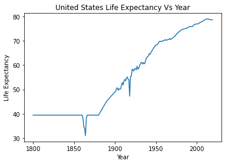

```python
plt.plot(year, rate)
plt.title('United States Life Expectancy Vs Year')
plt.xlabel('Year')
plt.ylabel('Life Expectancy')
plt.show()
```

### Find the happiness score of the United States throughout the years

```python
us_happy = df_happy_float.loc[df_happy_float['country'] == 'United States']
us_happy
```

|  | country | 2005 | 2006 | 2007 | 2008 | 2009 | 2010 | 2011 | 2012 | 2013 | 2014 | 2015 | 2016 | 2017 | 2018 | 2019 |
| --- | --- | --- | --- | --- | --- | --- | --- | --- | --- | --- | --- | --- | --- | --- | --- | --- |
| 153 | United States | 0.709357 | 0.718 | 0.751 | 0.728 | 0.716 | 0.716 | 0.712 | 0.703 | 0.725 | 0.715 | 0.686 | 0.68 | 0.699 | 0.688 | 0.694 |

```python
us_happy.isnull().sum().sum()
```

```
0
```

```python
us_happy = us_happy.drop(columns='country')
us_happy
```

|  | 2005 | 2006 | 2007 | 2008 | 2009 | 2010 | 2011 | 2012 | 2013 | 2014 | 2015 | 2016 | 2017 | 2018 | 2019 |
| --- | --- | --- | --- | --- | --- | --- | --- | --- | --- | --- | --- | --- | --- | --- | --- |
| 153 | 0.709357 | 0.718 | 0.751 | 0.728 | 0.716 | 0.716 | 0.712 | 0.703 | 0.725 | 0.715 | 0.686 | 0.68 | 0.699 | 0.688 | 0.694 |

```python
#plot the happiness score of the US
year = np.arange(2005,2020,1)
happy = us_happy.squeeze()
```

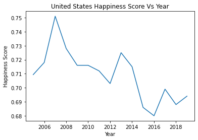

```python
plt.plot(year, happy)
plt.title('United States Happiness Score Vs Year')
plt.xlabel('Year')
plt.ylabel('Happiness Score')
plt.show()
```

### Find the income of the United States throughout the years

```python
us_income = df_income_2019.loc[df_income_2019['country'] == 'United States']
us_income
```

|  | country | 1800 | 1801 | 1802 | 1803 | 1804 | 1805 | 1806 | 1807 | 1808 | ... | 2010 | 2011 | 2012 | 2013 | 2014 | 2015 | 2016 | 2017 | 2018 | 2019 |
| --- | --- | --- | --- | --- | --- | --- | --- | --- | --- | --- | --- | --- | --- | --- | --- | --- | --- | --- | --- | --- | --- |
| 184 | United States | 1980 | 2020 | 2050 | 2020 | 2010 | 2060 | 2090 | 2110 | 1970 | ... | 49500 | 49900 | 50600 | 51200 | 52100 | 53200 | 53600 | 54500 | 55700 | 56700 |

1 rows × 221 columns

```python
us_income.isnull().sum().sum()
```

```
0
```

```python
us_income = us_income.drop(columns='country')
us_income
```

|  | 1800 | 1801 | 1802 | 1803 | 1804 | 1805 | 1806 | 1807 | 1808 | 1809 | ... | 2010 | 2011 | 2012 | 2013 | 2014 | 2015 | 2016 | 2017 | 2018 | 2019 |
| --- | --- | --- | --- | --- | --- | --- | --- | --- | --- | --- | --- | --- | --- | --- | --- | --- | --- | --- | --- | --- | --- |
| 184 | 1980 | 2020 | 2050 | 2020 | 2010 | 2060 | 2090 | 2110 | 1970 | 2060 | ... | 49500 | 49900 | 50600 | 51200 | 52100 | 53200 | 53600 | 54500 | 55700 | 56700 |

1 rows × 220 columns

```python
year = np.arange(1800,2020,1)
income = us_income.squeeze()
```

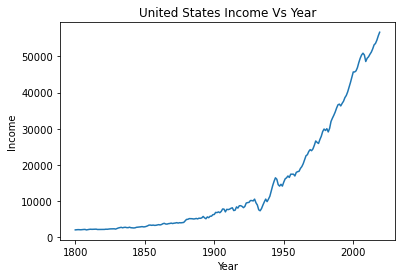

```python
plt.plot(year, income)
plt.title('United States Income Vs Year')
plt.xlabel('Year')
plt.ylabel('Income')
plt.show()
```

### Find the working hours of the United States throughout the years

```python
us_work_hr = df_work_hr.loc[df_work_hr['country'] == 'United States']
us_work_hr
```

|  | country | 1970 | 1971 | 1972 | 1973 | 1974 | 1975 | 1976 | 1977 | 1978 | ... | 2008 | 2009 | 2010 | 2011 | 2012 | 2013 | 2014 | 2015 | 2016 | 2017 |
| --- | --- | --- | --- | --- | --- | --- | --- | --- | --- | --- | --- | --- | --- | --- | --- | --- | --- | --- | --- | --- | --- |
| 120 | United States | 37.9952 | 37.9952 | 37.9952 | 37.9952 | 37.9952 | 37.9952 | 38.7 | 38.8 | 39 | ... | 36.7 | 35.7 | 36.1 | 36.2 | 36.4 | 36.6 | 36.6 | 36.6 | 36.7 | 36.6 |

1 rows × 49 columns

```python
us_work_hr.isnull().sum().sum()
```

```
0
```

```python
us_work_hr = us_work_hr.drop(columns='country')
us_work_hr
```

|  | 1970 | 1971 | 1972 | 1973 | 1974 | 1975 | 1976 | 1977 | 1978 | 1979 | ... | 2008 | 2009 | 2010 | 2011 | 2012 | 2013 | 2014 | 2015 | 2016 | 2017 |
| --- | --- | --- | --- | --- | --- | --- | --- | --- | --- | --- | --- | --- | --- | --- | --- | --- | --- | --- | --- | --- | --- |
| 120 | 37.9952 | 37.9952 | 37.9952 | 37.9952 | 37.9952 | 37.9952 | 38.7 | 38.8 | 39 | 38.9 | ... | 36.7 | 35.7 | 36.1 | 36.2 | 36.4 | 36.6 | 36.6 | 36.6 | 36.7 | 36.6 |

1 rows × 48 columns

```python
year = np.arange(1970,2018,1)
hours = us_work_hr.squeeze()
```

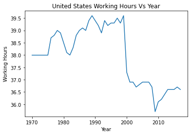

```python
plt.plot(year, hours)
plt.title('United States Working Hours Vs Year')
plt.xlabel('Year')
plt.ylabel('Working Hours')
plt.figsize=(40,10)
plt.show()
```

### Find the unemployment rate of the United States throughout the years

```python
us_unemp = df_unemp.loc[df_unemp['country'] == 'United States']
us_unemp
```

|  | country | 1947 | 1948 | 1949 | 1950 | 1951 | 1952 | 1953 | 1954 | 1955 | ... | 2008 | 2009 | 2010 | 2011 | 2012 | 2013 | 2014 | 2015 | 2016 | 2017 |
| --- | --- | --- | --- | --- | --- | --- | --- | --- | --- | --- | --- | --- | --- | --- | --- | --- | --- | --- | --- | --- | --- |
| 177 | United States | 0.039 | 0.038 | 0.059 | 0.053 | 0.033 | 0.03 | 0.029 | 0.055 | 0.044 | ... | 0.0578 | 0.0925 | 0.0963 | 0.0895 | 0.0807 | 0.0737 | 0.0617 | 0.0528 | 0.0487 | 0.0436 |

1 rows × 72 columns

```python
us_unemp.isnull().sum().sum()
```

```
0
```

```python
us_unemp = us_unemp.drop(columns='country')
us_unemp
```

|  | 1947 | 1948 | 1949 | 1950 | 1951 | 1952 | 1953 | 1954 | 1955 | 1956 | ... | 2008 | 2009 | 2010 | 2011 | 2012 | 2013 | 2014 | 2015 | 2016 | 2017 |
| --- | --- | --- | --- | --- | --- | --- | --- | --- | --- | --- | --- | --- | --- | --- | --- | --- | --- | --- | --- | --- | --- |
| 177 | 0.039 | 0.038 | 0.059 | 0.053 | 0.033 | 0.03 | 0.029 | 0.055 | 0.044 | 0.041 | ... | 0.0578 | 0.0925 | 0.0963 | 0.0895 | 0.0807 | 0.0737 | 0.0617 | 0.0528 | 0.0487 | 0.0436 |

1 rows × 71 columns

```python
year = np.arange(1947,2018,1)
rate =  us_unemp.squeeze()
```

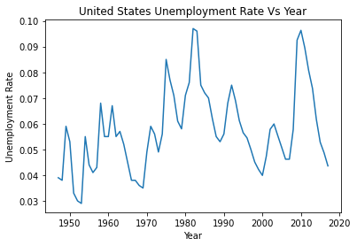

```python
plt.plot(year, rate)
plt.title('United States Unemployment Rate Vs Year')
plt.xlabel('Year')
plt.ylabel('Unemployment Rate')
plt.show()
```

### 1. Does a higher income lead to a higher life expectancy?

To explore this lets see how a scatter plot of life expectancy and income compare. Our data for US life expectancy and US income both have data from date ranges of 1800 to 2019 so no further trimming will be required!

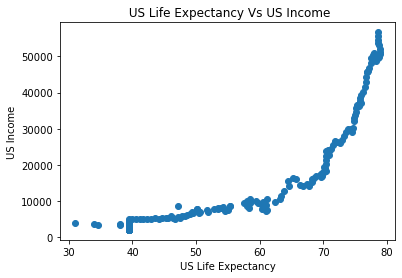

```python
plt.scatter(us_life_exp, us_income)
plt.title(' US Life Expectancy Vs US Income')
plt.xlabel('US Life Expectancy')
plt.ylabel('US Income')
plt.show()
```

We can see a strong positive correlation that as time goes on, we can tentativley say that a higher income in the United States can potentially mean a higher life expectancy

### 2. Does a higher unemployment rate lead to a lower life expectancy?

Our data for US unemployment ranges from 1947 to 2017 so we will trim our life expectancy data to match. Our life expectancy data is from dates ranging 1800 to 2019

1947 - 1800 = 147

```python
us_life_exp
```

|  | 1800 | 1801 | 1802 | 1803 | 1804 | 1805 | 1806 | 1807 | 1808 | 1809 | ... | 2010 | 2011 | 2012 | 2013 | 2014 | 2015 | 2016 | 2017 | 2018 | 2019 |
| --- | --- | --- | --- | --- | --- | --- | --- | --- | --- | --- | --- | --- | --- | --- | --- | --- | --- | --- | --- | --- | --- |
| 178 | 39.4 | 39.4 | 39.4 | 39.4 | 39.4 | 39.4 | 39.4 | 39.4 | 39.4 | 39.4 | ... | 78.7 | 78.8 | 78.9 | 78.9 | 78.9 | 78.8 | 78.6 | 78.6 | 78.6 | 78.6 |

1 rows × 220 columns

```python
us_life_exp_vs_unemp = us_life_exp.iloc[:, 147:-2]
us_life_exp_vs_unemp
```

|  | 1947 | 1948 | 1949 | 1950 | 1951 | 1952 | 1953 | 1954 | 1955 | 1956 | ... | 2008 | 2009 | 2010 | 2011 | 2012 | 2013 | 2014 | 2015 | 2016 | 2017 |
| --- | --- | --- | --- | --- | --- | --- | --- | --- | --- | --- | --- | --- | --- | --- | --- | --- | --- | --- | --- | --- | --- |
| 178 | 66.8 | 67.4 | 67.8 | 68.2 | 68.3 | 68.5 | 68.9 | 69.7 | 69.7 | 69.8 | ... | 78.2 | 78.4 | 78.7 | 78.8 | 78.9 | 78.9 | 78.9 | 78.8 | 78.6 | 78.6 |

1 rows × 71 columns

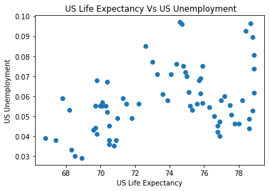

```python
plt.scatter(us_life_exp_vs_unemp, us_unemp)
plt.title(' US Life Expectancy Vs US Unemployment')
plt.xlabel('US Life Expectancy')
plt.ylabel('US Unemployment')
plt.show()
```

There is a weak positive correlation. No conclusions can be drawn for the relation of these variables

### 3. Does a higher hours worked per week lead to a higher life expectancy?

Our data for US work hours range from 1970 to 2017 so we will trim our life expectancy data to match. Our life expectancy data is from dates ranging 1800 to 2019

1970 - 1800 = 170

```python
us_life_exp
```

|  | 1800 | 1801 | 1802 | 1803 | 1804 | 1805 | 1806 | 1807 | 1808 | 1809 | ... | 2010 | 2011 | 2012 | 2013 | 2014 | 2015 | 2016 | 2017 | 2018 | 2019 |
| --- | --- | --- | --- | --- | --- | --- | --- | --- | --- | --- | --- | --- | --- | --- | --- | --- | --- | --- | --- | --- | --- |
| 178 | 39.4 | 39.4 | 39.4 | 39.4 | 39.4 | 39.4 | 39.4 | 39.4 | 39.4 | 39.4 | ... | 78.7 | 78.8 | 78.9 | 78.9 | 78.9 | 78.8 | 78.6 | 78.6 | 78.6 | 78.6 |

1 rows × 220 columns

```python
us_life_exp_vs_work = us_life_exp.iloc[:, 170:-2]
us_life_exp_vs_work
```

|  | 1970 | 1971 | 1972 | 1973 | 1974 | 1975 | 1976 | 1977 | 1978 | 1979 | ... | 2008 | 2009 | 2010 | 2011 | 2012 | 2013 | 2014 | 2015 | 2016 | 2017 |
| --- | --- | --- | --- | --- | --- | --- | --- | --- | --- | --- | --- | --- | --- | --- | --- | --- | --- | --- | --- | --- | --- |
| 178 | 71.0 | 71.3 | 71.5 | 71.8 | 72.2 | 72.6 | 73.0 | 73.3 | 73.6 | 73.9 | ... | 78.2 | 78.4 | 78.7 | 78.8 | 78.9 | 78.9 | 78.9 | 78.8 | 78.6 | 78.6 |

1 rows × 48 columns

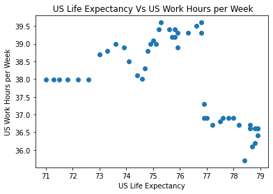

```python
plt.scatter(us_life_exp_vs_work, us_work_hr)
plt.title(' US Life Expectancy Vs US Work Hours per Week')
plt.xlabel('US Life Expectancy')
plt.ylabel('US Work Hours per Week')
plt.show()
```

Lets compare this data to the hours worked per week in the USA. I will copy the code for the line graph generated a few lines above

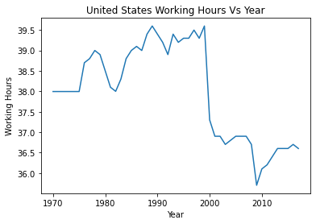

```python
year = np.arange(1970,2018,1)
hours = us_work_hr.squeeze()
plt.plot(year, hours)
plt.title('United States Working Hours Vs Year')
plt.xlabel('Year')
plt.ylabel('Working Hours')
plt.show()
```

We can see that there was a drop in the average working hours per week around the late 1990's by roughly two and a half hours. The weekly hours worked seems to have also stayed around the reduced level since then. This can explain the gap in the scatter plot. However no relation between work hours and life expectancy can be deduced.

### 4. Does a higher hours worked per week lead to a happier nation?

2005 - 1970 = 35

```python
# trim  us_work_hr
us_work_hr_vs_happy = us_work_hr.iloc[:, 35:]
us_work_hr_vs_happy
```

|  | 2005 | 2006 | 2007 | 2008 | 2009 | 2010 | 2011 | 2012 | 2013 | 2014 | 2015 | 2016 | 2017 |
| --- | --- | --- | --- | --- | --- | --- | --- | --- | --- | --- | --- | --- | --- |
| 120 | 36.9 | 36.9 | 36.9 | 36.7 | 35.7 | 36.1 | 36.2 | 36.4 | 36.6 | 36.6 | 36.6 | 36.7 | 36.6 |

```python
#trim us_happy
us_happy_vs_work = us_happy.iloc[:, :-2]
us_happy_vs_work
```

|  | 2005 | 2006 | 2007 | 2008 | 2009 | 2010 | 2011 | 2012 | 2013 | 2014 | 2015 | 2016 | 2017 |
| --- | --- | --- | --- | --- | --- | --- | --- | --- | --- | --- | --- | --- | --- |
| 153 | 0.709357 | 0.718 | 0.751 | 0.728 | 0.716 | 0.716 | 0.712 | 0.703 | 0.725 | 0.715 | 0.686 | 0.68 | 0.699 |

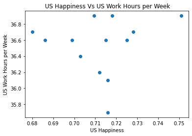

```python
plt.scatter(us_happy_vs_work, us_work_hr_vs_happy)
plt.title(' US Happiness Vs US Work Hours per Week')
plt.xlabel('US Happiness')
plt.ylabel('US Work Hours per Week')
plt.show()
```

No correleation is seen here

### 5. Does a higher income mean a nation is more happy?

2005 - 1800 = 205

```python
us_income_vs_happy = us_income.iloc[:, 205:]
us_income_vs_happy
```

|  | 2005 | 2006 | 2007 | 2008 | 2009 | 2010 | 2011 | 2012 | 2013 | 2014 | 2015 | 2016 | 2017 | 2018 | 2019 |
| --- | --- | --- | --- | --- | --- | --- | --- | --- | --- | --- | --- | --- | --- | --- | --- |
| 184 | 49500 | 50400 | 50900 | 50400 | 48600 | 49500 | 49900 | 50600 | 51200 | 52100 | 53200 | 53600 | 54500 | 55700 | 56700 |

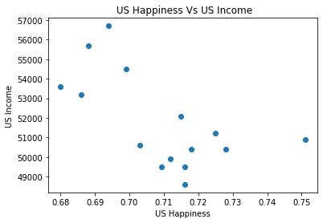

```python
plt.scatter(us_happy, us_income_vs_happy)
plt.title(' US Happiness Vs US Income')
plt.xlabel('US Happiness')
plt.ylabel('US Income')
plt.show()
```

We can see a slighlty negative correlation. We can tentatively say that a lower income can potentially mean a higher happiness score. Note that the income levels shown in the scatter plot is well above the United States poverty line by at least 3X.

The poverty line as of 2020 for a 1 person house hold is $12,760

This information was sourced from [here](https://www.payingforseniorcare.com/federal-poverty-level)

### 6. Does a higher unemployment rate mean a nation is less happy?

We will need to trim our unemployemnt data to match, and also trim our happiness data score to 2017.

Our US unemployment data is from dates ranging 1947 to 2017

2005 - 1947 = 58

```python
#trim unemployment
us_unemp_vs_happy = us_unemp.iloc[:, 58:]
us_unemp_vs_happy
```

|  | 2005 | 2006 | 2007 | 2008 | 2009 | 2010 | 2011 | 2012 | 2013 | 2014 | 2015 | 2016 | 2017 |
| --- | --- | --- | --- | --- | --- | --- | --- | --- | --- | --- | --- | --- | --- |
| 177 | 0.0508 | 0.0462 | 0.0462 | 0.0578 | 0.0925 | 0.0963 | 0.0895 | 0.0807 | 0.0737 | 0.0617 | 0.0528 | 0.0487 | 0.0436 |

```python
#trim happy
us_happy_vs_unemp = us_happy.iloc[:, :-2]
us_happy_vs_unemp
```

|  | 2005 | 2006 | 2007 | 2008 | 2009 | 2010 | 2011 | 2012 | 2013 | 2014 | 2015 | 2016 | 2017 |
| --- | --- | --- | --- | --- | --- | --- | --- | --- | --- | --- | --- | --- | --- |
| 153 | 0.709357 | 0.718 | 0.751 | 0.728 | 0.716 | 0.716 | 0.712 | 0.703 | 0.725 | 0.715 | 0.686 | 0.68 | 0.699 |

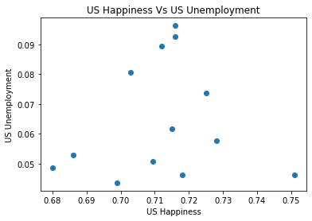

```python
plt.scatter(us_happy_vs_unemp, us_unemp_vs_happy)
plt.title('US Happiness Vs US Unemployment')
plt.xlabel('US Happiness')
plt.ylabel('US Unemployment')
plt.show()
```

No clear correlation is seen therefore, no conclusions can be tentatively inferred about Happiness and Unemployemnt in the United States

## Conclusion

#### Does a higher income lead to a higher life expectancy?

We can see a strong positive correlation between higher income and higher life expectancy. However, since this study has not performed any inferential statistics we cannot say for sure that a higher income leads to a higher life expectancy.

#### Does a higher unemployment rate lead to a lower life expectancy?

The charts created show a weak positive correlation but also show that towards the right side a little above 78 years old we see unemployment numbers of all ranges. The average, combined genders, US life expectancy in 2017, which is the range for the data used was 78.6 according to the [CDC](https://www.cdc.gov/nchs/products/databriefs/db328.htm). No significant correlation can be determined.

#### Does a higher hours worked per week lead to a higher life expectancy?

During the late 1990's we can see a significant drop in working hours. And after that change happened, life expectancy did go go up. However we cannot say for certain that this increase in life expectancy is due to shortened work hours. It would be interesting to look further into but this is beyond the scope of this study.

#### Does a higher hours worked per week lead to a happier nation?

No correlation is observed

#### Does a higher income mean a nation is more happy?

We can see a slighlty negative correlation. This implies that a slightly lower income means more happiness. However we cannot say for certain that higher happiness score is a direct causation lower income. There could be many other factors that go into this such as more income could mean more hours worked and therefore less time for leisure and other factors affecting happiness score.

It is worth noting again that the income levels shown in the data is well above the United States poverty line by at least a facor of 3. The federal poverty line for the United States in 2020 is $ 12,760. The poverty line data is sourced from [here](https://www.payingforseniorcare.com/federal-poverty-level)

#### Does a higher unemployment rate mean a nation is less happy?

No strong correlation is observed between unemployment and the happiness score

### Limitations

Only descriptive statistics was used throughout answering these questions and since no inferential statistics was used we cannot say our findings are correlation implying causation.

For our last 3 questions we have a signficantly smaller date range from 2005-2017 compared to the first 3 questions which have a data from as far back as 1800.

A few of the dataframes we used have null values which were filled in using the mean value for the dataset as shown in the process above.